# Setup

```
The autoreload extension is already loaded. To reload it, use:
  %reload_ext autoreload
```

# Load data

The experiment data consists of multiple matfiles corresponding to the data for different subjects. Each matfile contains that subject's push, eye tracking (if available), and position (if available) data organized by blocks and sessions. Each block corresponds to a set of experiment parameters, notably the schedule of each box, the stimulus reliability kappa, and the stimulus type. A hierarchical overview of a given matfile is given in the `Angelaki Data Cleaning` notebook.

|  | box | push times | reward outcomes |
| --- | --- | --- | --- |
| ('humans', 1, 1, 1, 'availability', 10, 'high', 0.1, nan) | medium | 3.85065 | False |
| ('humans', 1, 1, 2, 'availability', 10, 'high', 0.1, nan) | slow | 7.88168 | False |
| ('humans', 1, 1, 3, 'availability', 10, 'high', 0.1, nan) | fast | 11.1914 | True |
| ('humans', 1, 1, 4, 'availability', 10, 'high', 0.1, nan) | medium | 14.5342 | False |
| ('humans', 1, 1, 5, 'availability', 10, 'high', 0.1, nan) | slow | 17.7104 | False |

### Information

#### Fisher Information

The Fisher information tells us how discriminable the experiment parameters, such as the schedules, of the experiment are from similar parameters-- the higher the Fisher information, the higher the theoretical limit on our knowledge or certainty about the parameters. This relationship is formally known as the Cramer-Rao lower bound, which states that the variance of any unbiased estimator can be no lower than the inverse Fisher information. For example, if the subject knew the reward times $\{t_r\}$ exactly, then they could average them to get an estimate of the mean schedule, whose variance would be minimal among all estimators and thus equal to the inverse Fisher information.

Alas, in reality, the subject's observations take the form of 1) censored observations $(r_t \in \{0, 1\})$ ie. was reward available by the time they pushed at time $t$ 2) noisy color cues that encode the reward time $o(t_r)$. These observations carry less information about the schedule than direct observations of the reward time, so naturally the variance of the estimators using these observations will not be minimal. Nonetheless, it is useful to know an upper bound on the precision of the estimation problem. We derive the Fisher information of the mean schedule ($\lambda$) as a function of the wait time ($t$), and the shape parameter ($\alpha$), using only observations about reward.

$$J(\lambda) = (\frac{t}{\lambda})^2 \frac{f^2(t|\lambda, \alpha)}{F(t|\lambda, \alpha)(1-F(t|\lambda, \alpha))}$$

Here, we show the Fisher information as a function of wait time for different boxes, along with the optimal waiting times that maximize the Fisher information, under the gamma schedule. The exponential schedule will be treated separately in a supplementary notebook.

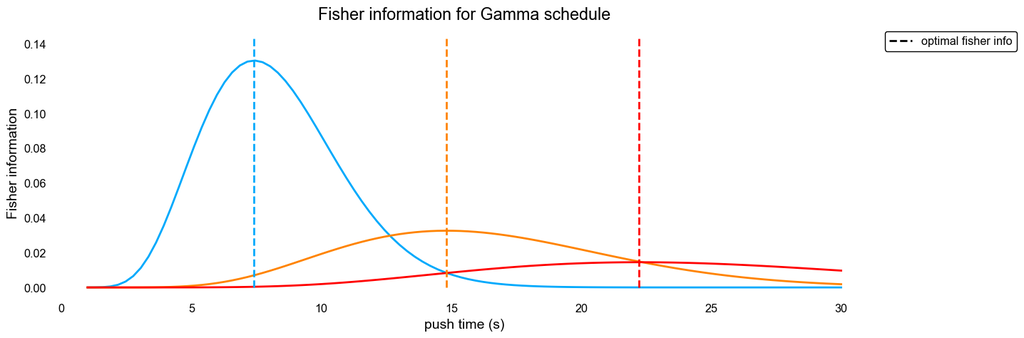

The optimal wait times that maximize the Fisher information of each box occur at distinct timepoints ordered by mean schedules. Notice that the maximal Fisher information of the two slower boxes are close together in value compared to the fast box, suggesting that the fast box may be easiest to figure out first because it requires not only fewer but also shorter pushes to reach a certain precision. We show how the precision grows with more observations by showing how the standard deviation, the square root of the Cramer-Rao lower bound, decreases with the number of obervations.

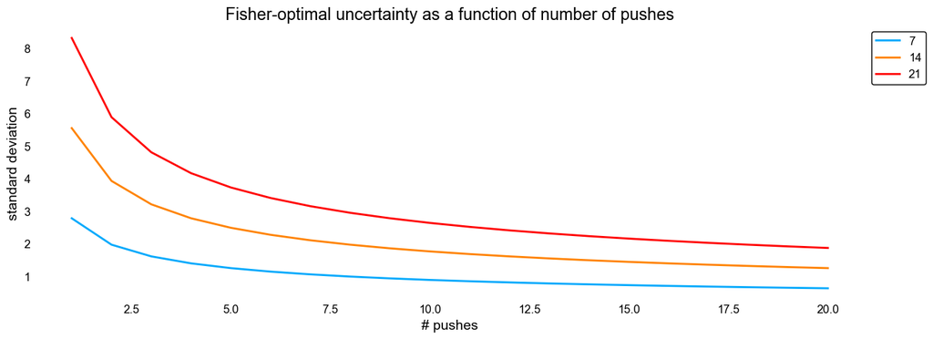

To get an estimate of the schedule down to within ±2-3 of the true schedule, one immediately starts of with such a precision after one push at the fast box under the gamma schedule. After 15-20 pushes, the precision of all boxes goes down to at least ±2-3 of the true schedule.

# Beliefs about schedule

Now that we have a sense of the theoretical upper bound on learning the schedules, we will look at the beliefs that a subject performing exact Bayesian inference may form over the actual censored observations $\{r_t\}$. We will consider the posteriors of each box to be pairwise independent and with uniform prior starting each block. The likelihood function is merely the cumulative density function $F$ of the gamma distribution if reward is delivered, and one minus this function otherwise. It is defined below for notational convenience:

$$L(r_t) = \begin{cases} F(t) & \text{for } r_t = 1 \\ 1-F(t) & \text{for } r_t = 0 \end{cases}$$

Here is an example block's belief trajectories.

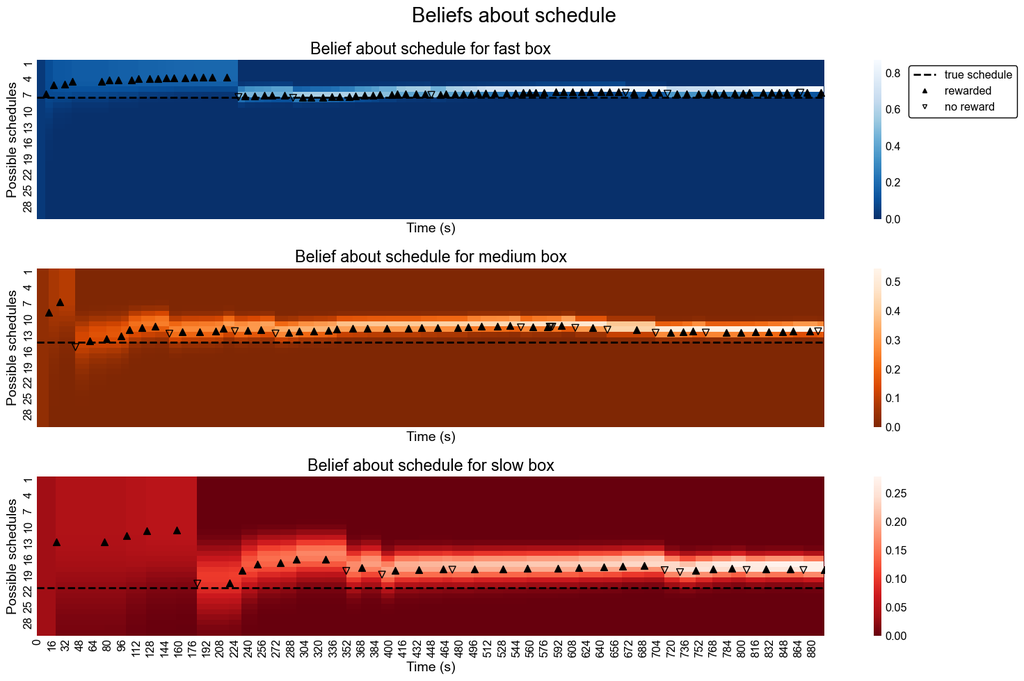

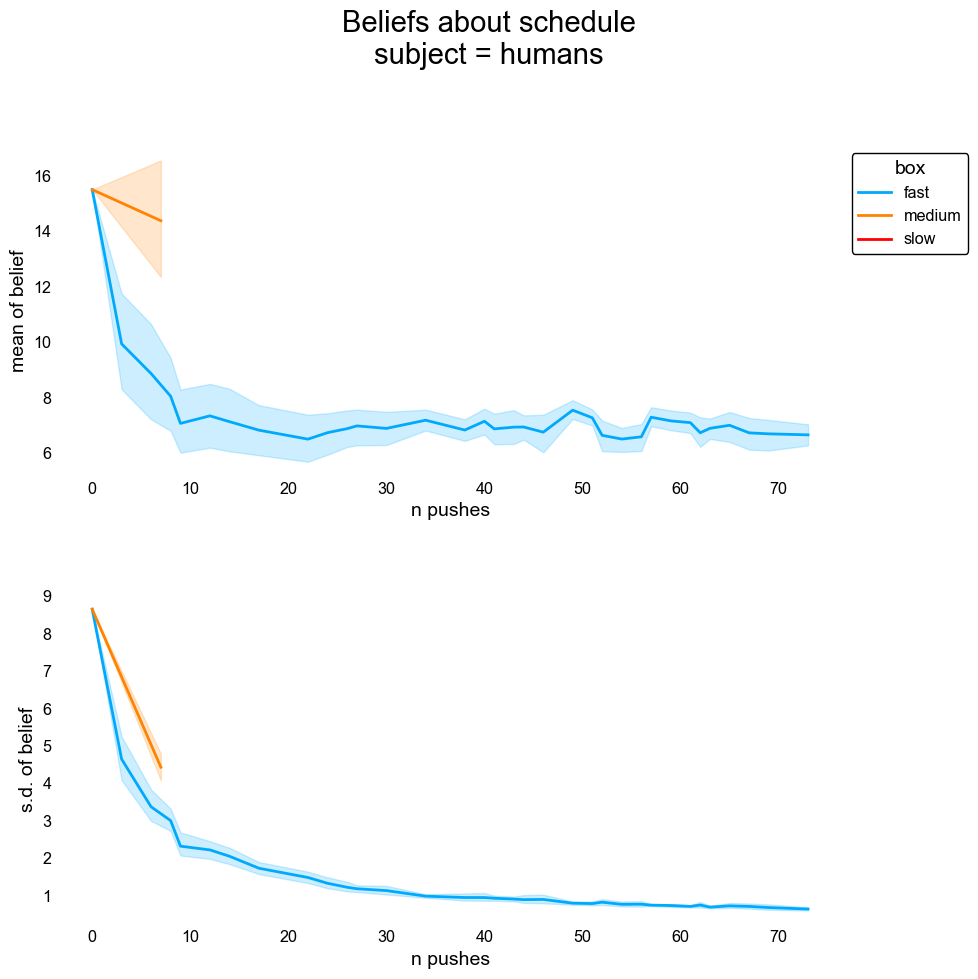

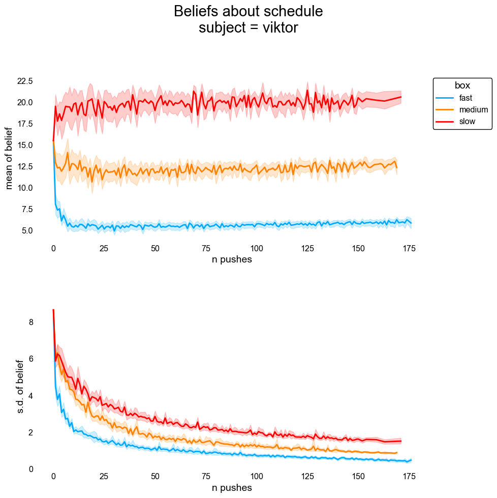

[figure not shown]

[figure not shown]

| subject | session | block | push # | mean of belief | s.d. of belief | push times | box | n pushes |
| --- | --- | --- | --- | --- | --- | --- | --- | --- |
| humans | 1 | 1 | -2 | 15.500000 | 8.655441 | 0.00000 | medium | 0 |
|  |  |  | -1 | 15.500000 | 8.655441 | 0.00000 | medium | 0 |
|  |  |  | 0 | 15.500000 | 8.655441 | 0.00000 | medium | 0 |
|  |  |  | 1 | 19.407489 | 6.586283 | 7.88168 | slow | 1 |
|  |  |  | 2 | 7.226431 | 4.804480 | 11.19139 | fast | 2 |
| ... | ... | ... | ... | ... | ... | ... | ... | ... |
| viktor | 20230824 | 10 | 115 | 4.409716 | 2.382503 | 863.09200 | medium | 115 |
|  |  |  | 116 | 4.404367 | 2.377719 | 879.99500 | medium | 116 |
|  |  |  | 117 | 17.516272 | 1.580683 | 883.18200 | slow | 117 |
|  |  |  | 118 | 3.094362 | 1.599493 | 887.21700 | fast | 118 |
|  |  |  | 119 | 17.211592 | 1.534541 | 900.92200 | slow | 119 |

26000 rows × 5 columns

Here are the beliefs from an example block. Feel free to change the `index` values to change the block to display. You can also change `x_col` parameter to `push times` or even `push # by box` which shows the beliefs as a function of experience at each box.

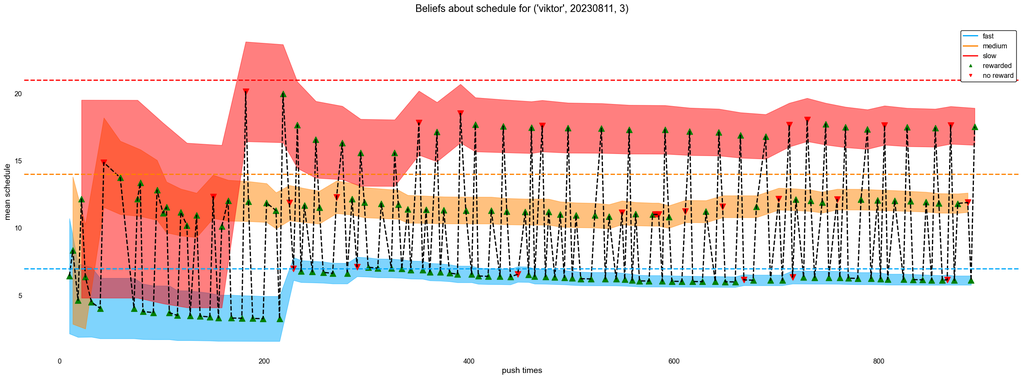

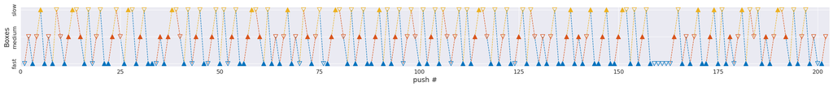

Aggregating across blocks, these are the means and uncertainties for Viktor, aligned by experience at each box.

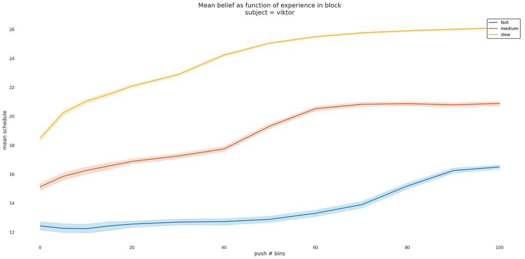

```
Legend
```

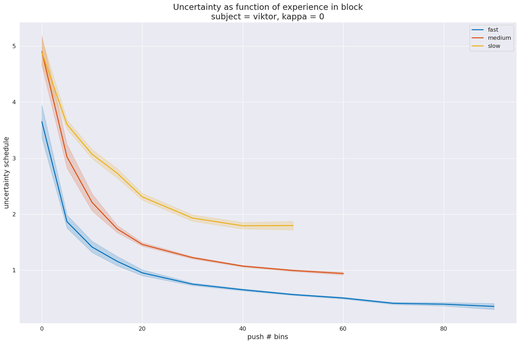

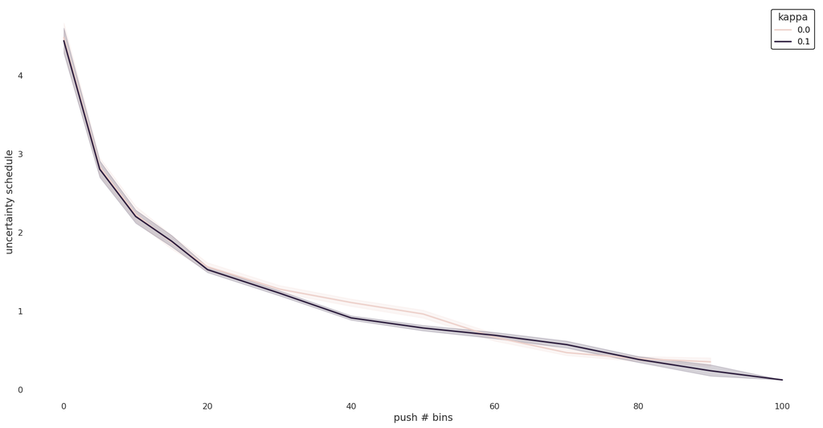

## Likelihood

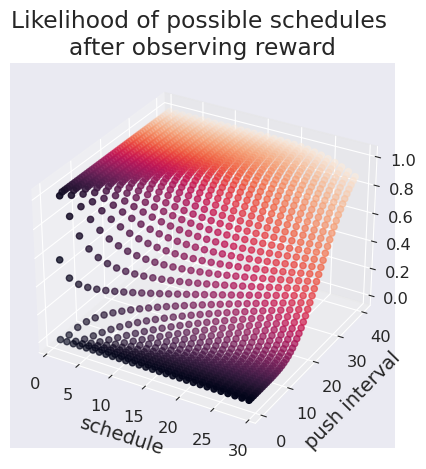

# Reward beliefs

```
<Axes3D: title={'center': 'Belief about reward availability \nat time of push for viktor'}, xlabel='Belief that reward is available at fast box', ylabel='Belief that reward is available at medium box', zlabel='Belief that reward is available at slow box'>
```

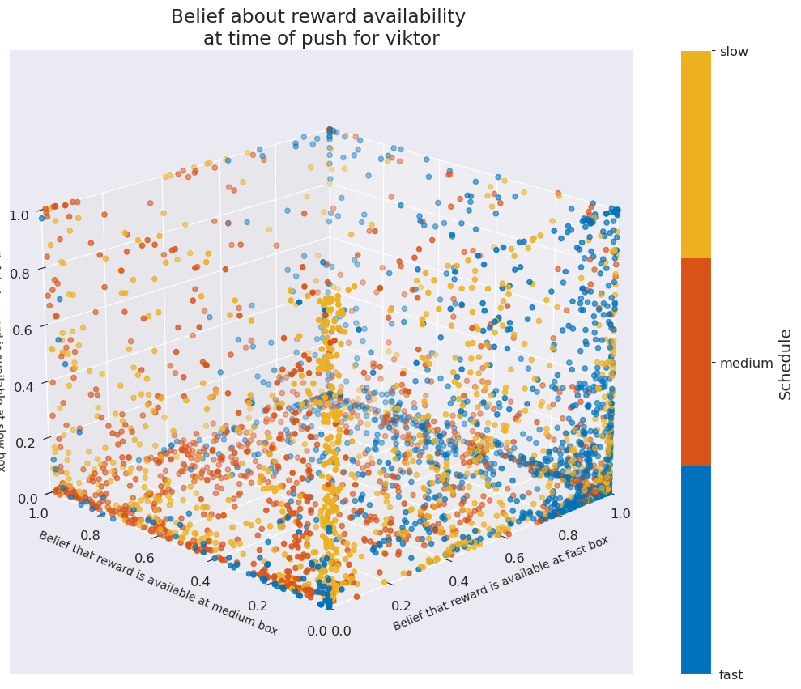

```
<Axes3D: title={'center': 'Exact reward probability \nat time of push for viktor'}, xlabel='Belief that reward is available at fast box', ylabel='Belief that reward is available at medium box', zlabel='Belief that reward is available at slow box'>
```

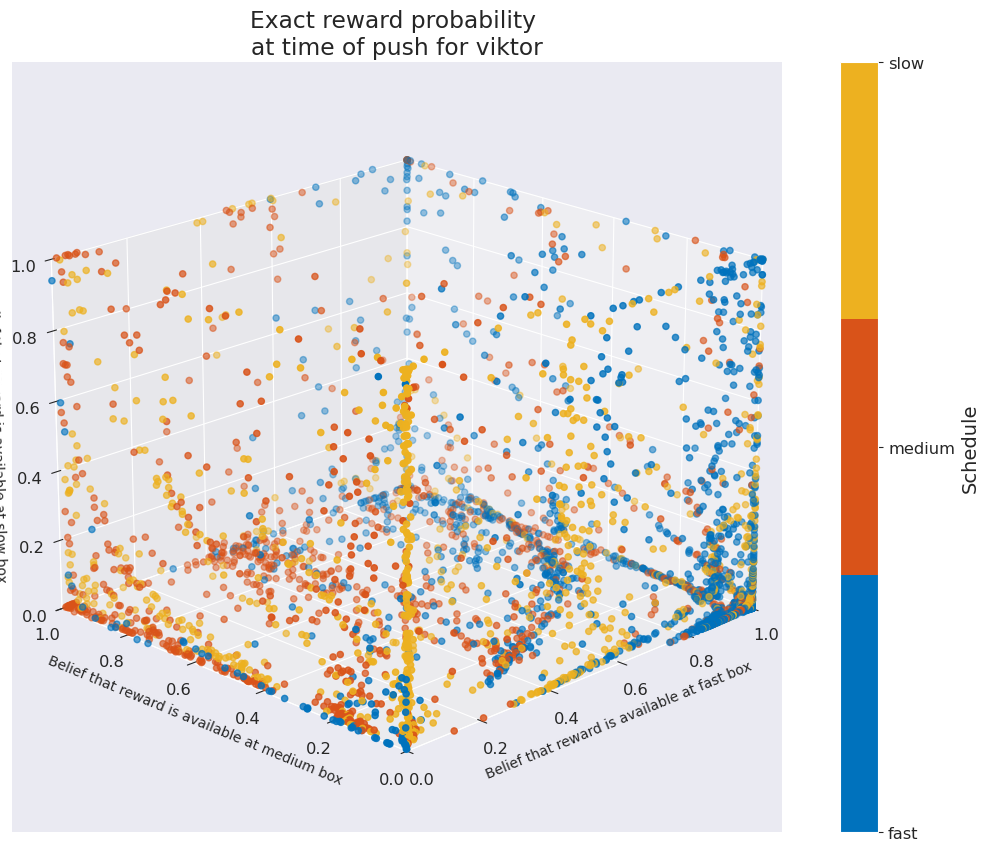

## Predict pushed box

```
marginal belief results:
	(accuracy, p-value) = (0.6054308672762538, 0.0)
	(r-squared, p-value) = (0.18314803645579225,0.0)
perfect model results:
	(accuracy, p-value) = (0.6070933776669437, 0.0)
	(r-squared, p-value) = (0.18392538584348228,0.0)
```

```
Group: 0
result (0.5924242424242424, np.float64(0.22847079605339538), np.float64(0.0), np.float64(0.0), LogisticRegression())

Group: 5
result (0.5866666666666667, np.float64(0.17603436283475005), np.float64(0.0), np.float64(0.0), LogisticRegression())

Group: 10
result (0.6086941580756013, np.float64(0.20177425703401697), np.float64(0.0), np.float64(0.0), LogisticRegression())

Group: 15
result (0.5939642034378877, np.float64(0.2191659909058743), np.float64(0.0), np.float64(0.0), LogisticRegression())

Group: 20
result (0.5812395309882747, np.float64(0.18034534279778225), np.float64(0.0), np.float64(0.0), LogisticRegression())

Group: 30
result (0.5481334143131896, np.float64(0.1562185498839166), np.float64(0.0), np.float64(0.0), LogisticRegression())

Group: 40
result (0.591144129155126, np.float64(0.18870711181462618), np.float64(0.0), np.float64(0.0), LogisticRegression())

Group: 50
result (0.5963146841998618, np.float64(0.18555183362763727), np.float64(0.0), np.float64(0.0), LogisticRegression())

Group: 60
result (0.5768659236744343, np.float64(0.0913764281861611), np.float64(0.0), np.float64(1.0), LogisticRegression())

Group: 70
result (0.7191506410256409, np.float64(0.062009277377538585), np.float64(0.056), np.float64(1.0), LogisticRegression())

Group: 80
skipped!

Group: 90
skipped!

Group: 100
skipped!
```

```
Group: 0
result (0.5889225589225588, np.float64(0.23322841211691414), np.float64(0.0), np.float64(0.0), LogisticRegression())

Group: 5
result (0.5966666666666667, np.float64(0.18136165070424237), np.float64(0.0), np.float64(0.0), LogisticRegression())

Group: 10
result (0.615257731958763, np.float64(0.20810975343636584), np.float64(0.0), np.float64(0.0), LogisticRegression())

Group: 15
result (0.6142743221690591, np.float64(0.21770158254059946), np.float64(0.0), np.float64(0.0), LogisticRegression())

Group: 20
result (0.58490699109583, np.float64(0.18227594545731118), np.float64(0.0), np.float64(0.0), LogisticRegression())

Group: 30
result (0.5468144549043426, np.float64(0.15854546084460552), np.float64(0.0), np.float64(0.0), LogisticRegression())

Group: 40
result (0.6007537322383127, np.float64(0.19104694904890218), np.float64(0.0), np.float64(0.0), LogisticRegression())

Group: 50
result (0.5923748182316622, np.float64(0.17934012921822218), np.float64(0.0), np.float64(0.0), LogisticRegression())

Group: 60
result (0.5840932117527863, np.float64(0.0861435237446756), np.float64(0.0), np.float64(1.0), LogisticRegression())

Group: 70
result (0.7243589743589741, np.float64(0.06017128696228413), np.float64(0.062), np.float64(1.0), LogisticRegression())

Group: 80
skipped!

Group: 90
skipped!

Group: 100
skipped!
```

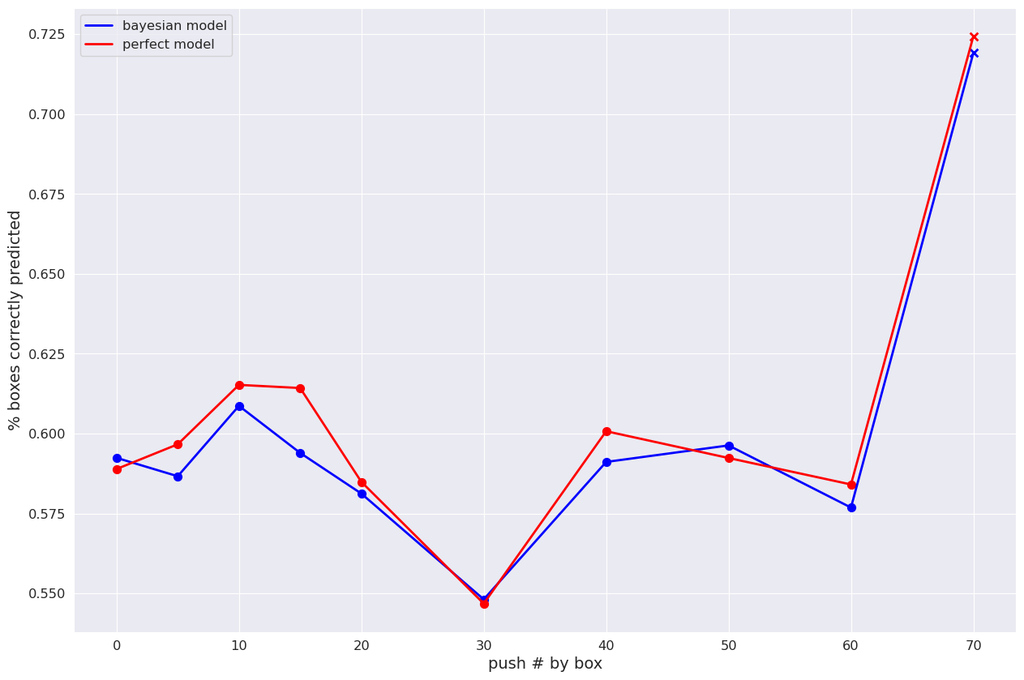

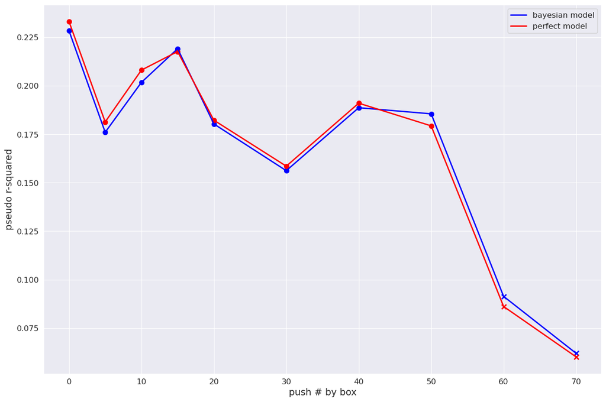

## Likelihood under probabilistic policy with negligible action costs

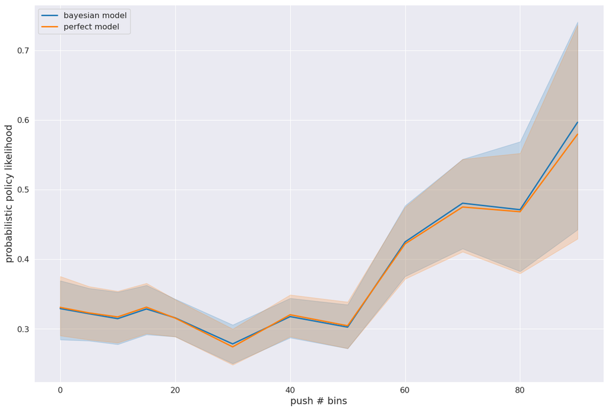

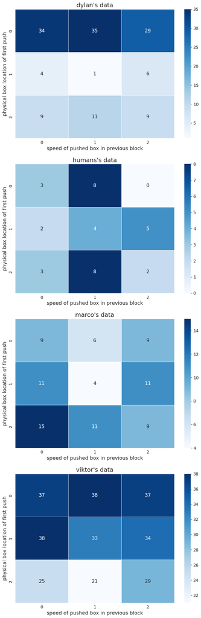

# Thompson sampling

```
23 4 18 9 16 11
80 37 33
```

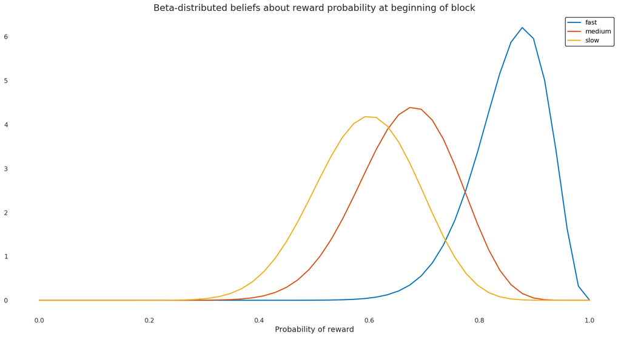